# Public Indebtedness and Foreign Credit Demand for Sovereign Bonds

Augusto Netto, Gabriella Garcia and Maria Clara Drzeviechi

**Insper Data**

# 1 Objective

This study aims to investigate the economic determinants of foreign participation in a country’s public debt. Investors, when allocating resources in foreign countries, can look for different things such as stability, higher returns or just diversification of assets. Each country can serve to fulfill one of these objectives and, depending on the macroeconomic fundamentals, they can be more or less attractive to investors. In addition, it is necessary to analyze emerging and advanced countries separately, considering that these two groups have very divergent characteristics. Thus, this work wants to understand which are the macroeconomic determinants that can attract or put away bondholders, for both advanced or emerging countries.

# 2 Introduction

In the past 50 years, emerging and developing economies experienced four big indebtedness waves, three of which ended up in financial crises. In the 1980s, the association of low real interest rates and the growing debt market led certain economies to raise considerably their levels of indebtedness; the result was the well-known Latin America’s debt crisis. A decade later, the world would watch the Asian financial crisis, due to the liberalization of financial markets and capital flows, allowing these countries to acquire loans in foreign currencies. Finally, in 2007-09, both emerging and advanced economies faced major recessions as a result of the global financial crisis.

It is important to notice that although happening in different decades and locations, these three episodes share a common denominator: they all started in periods with low real interest rates and an escalating indebtedness. This scenario made the risk premium rise and subsequently there was a sudden stop of capital flows.

In 2010, the fourth global wave of debt started, and it was the largest and fastest one. In accordance with the aforementioned debt crisis, interest rates were low since the Global Financial Crisis of 2008 and investors were seeking assets with greater profitability. It is also reasonable to consider that this wave has not yet met its end. By 2018, according to the International Monetary Fund, global debt has reached 226% of GDP, representing an amount of 188 trillions of dollars. Emerging and developing economies saw indebtedness grow 54 p.p. in 8 years, reaching 170% of their GDP. Low income countries reached 67% of debt over GDP in 2018, that figure being 48% in 2010. A different situation is seen on advanced economies, once they have maintained a ratio of around 265% debt to GDP, the same level since 2010.

Global debt waves have shown the need for emerging and developing markets to develop their sovereign bond markets to facilitate public debt financing and management, primarily through the issuance of domestic bonds in local currencies. This growth was reflected on the increase of domestic participation in government bonds, as well as on the increase of foreign interest in the debt of these governments, which has become increasingly relevant to local bond markets.

The raise in foreign participation in the sovereign debt market is also related to many susceptible advantages, such as a decrease in government borrowing costs, due to the higher demand for these bonds, presented in several studies (Andritzky, 2012; Arslanalp and Poghosyan, 2014; Jaramillo and Zhang, 2013; Warnock and Warnock, 2009); and the diversification of the investor base, reflecting different characteristics of investors in terms of risk tolerance and trading reasons, which may increase the liquidity of government debt bonds in the secondary market (World Bank and IMF, 2001).

However, foreign investors tend to be relatively more sensitive to risk, particularly foreign private investors, and can be an unstable source of demand in times of stress, as they have a broader pool of assets in which they can invest. As a result, they may be less inclined to maintain their participation during episodes such as the ones treated here (Broner et al., 2013).

The constant rise in indebtedness, observed in the current wave of global debt and intensified by the current crisis of COVID-19, may culminate in a sudden increase in risk premiums, if investors consider debt to GDP levels to be unsustainable (Blanchard 2019; Henderson 2019; Rogoff 2019a, b). If this happens, both capital inflows and outflows are expected to decrease, as has happened during other economic crises, with this effect being stronger in global crises (Broner et al., 2013), which further complicates the ability of countries to manage their debt.

In this context, this study aims to analyze the different impacts of public debt on the participation of foreign creditors in government bonds, depending on different scenarios and macroeconomic fundamentals. Given the negative relationship between the level of public debt and foreign investors already explored in the literature, we will investigate how this effect varies over time and conditions.

# 3 Literature Review

Discussions on how indebtedness can affect the macroeconomic variables of a country are widely addressed in the literature. The main topics are related to foreign investors; growth; debt overhang and debt tolerance.

Initially, countries’ ability to attract non-local investors was studied by Burger and Warnok (2005). Their study shows that countries with a history of low inflation tend to have a more developed bond market. Subsequently, Brutti and Sauré (2012) studied the importance of a derivatives market for the quality of a bond market.

In this study, it is important to highlight the developed literature from Arslanap and Tsuda (2014). The authors, in addition to having compiled the database used in this article, carried out several analisis on foreign participation in the bond market. It was noted that, as of 2010, there was a great flow of foreign capital to the emerging securities market. In addition, they concluded that countries with a lower debt-to-GDP ratio were more attractive to foreign investors.

The relationship between debt and growth was first found to be non-linear by Reinhart, Rogoff, and Savastano (2003). Later, Reinhart and Rogoff (2010) analyzed countries distinguishing developed and emerging markets, finding out that, for both groups, a 90% debt to GDP ratio can be detrimental for growth. On the other hand, Kumar and Woo (2010) produced evidence that the negative impact of debt on growth is higher for developing countries when compared with developed countries.

Thinking about debt tolerance, Reinhart, Rogoff and Savastano (2003) introduce the concept of debt intolerance and analyze how emerging markets find it difficult to face high levels of debt, while advanced countries face this issue more easily. Later, Catão and Kapur (2006) discussed the macroeconomic determinants of a country’s volatility and how it impacts the spread rate it has to pay.

The concept of debt overhang refers to a debt burden so large that the country can not take any additional debt to finance itself. Krugman (1988) discussed the tradeoff for creditors when facing a debt overhang: financing or forgiving. Deshpande (1995) discusses how a situation of debt overhang can discourage investment. Reinhart, Reinhart, and Rogoff (2012) punctuated the main episodes in history about debt overhang.

# 4 Dataset

The dataset used in this study is composed by the database provided by Arslanalp and Takahiro Tsuda, previously affiliated with the Monetary and Capital Markets Department of the International Monetary Fund. Arslanalp and Takahiro Tsuda provide estimates of investor holdings of government debt of 24 advanced economies and 24 emerging market economies.

The investor base is grouped under six classes: domestic central bank, domestic banks, domestic nonbanks, foreign official sector, foreign banks, and foreign nonbanks. Banks include depository institutions other than central banks, based on the definition used in the IMF’s International Financial Statistics (IFS). Nonbanks include other investors, including insurance companies, pension funds, and investment funds. Investment funds could be mutual funds, exchange-traded funds (ETFs), or sovereign wealth funds (SWFs). The foreign official sector for Emerging Markets includes official loans and foreign central bank holdings of EM government debt as reserve assets, and for Advanced Markets includes foreign central banks and other foreign official creditors.

For this study, 45 of the 48 countries present at the base of Arslanalp and Tsuda are used. The data are annualized through the fourth quarter of each year and the sample period used covers the years 2004 to 2019.

Macroeconomic and financial data were obtained from the World Economic Outlook Database published by the International Monetary Fund in April 2020. For countries where the nominal interest rate was incomplete on the basis of the IMF, the missing data was obtained on the website of the central banks in each country.

# 5 Stylized Facts About the Database

Given the recovery of economies affected by the Asian financial crisis (1990s), global indebtedness resumed at an accelerated pace. This coincided with a period of rapid expansion for banks based in the United States and the European Union (Arteta and Kasyanenko 2019). The consequence was the start of the third wave of global debt in 2002, due to the sharp increase in lending from emerging markets in international debt markets, given the low global interest rates. In 2004, six emerging markets were among the ten countries with the highest levels of debt to GDP (graph 1). In contrast, the emerging markets with the largest share of foreign investors were not the most indebted countries (graph 2). Over the years, advanced markets have become the countries with the highest levels of debt to GDP, but in relation to the percentage of foreign investors in public debt, emerging countries continued to be present in the ranking.

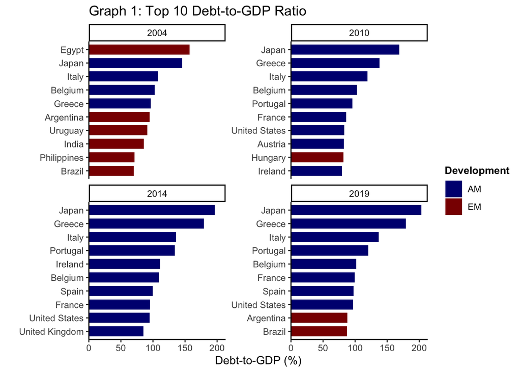

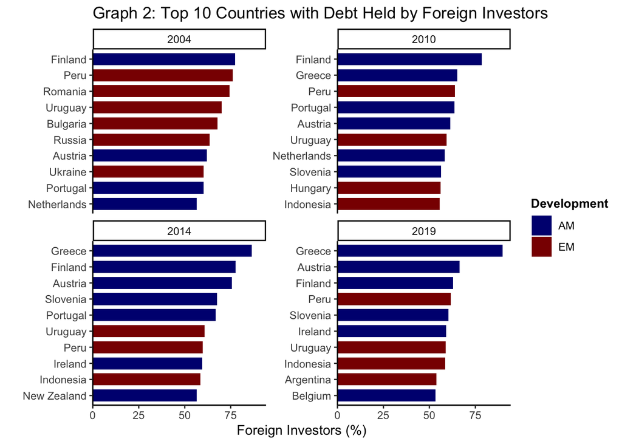

In addition, low inflation and fiscal stabilization in many emerging markets before the third global wave of debt, contributed to an increase in the credibility of macroeconomic policies (Kose and Ohnsorge, 2019) and to the development of the bond market in these countries. Thus, the third global wave of debt had a lesser effect on emerging markets, given the improvement in fiscal balances and debt management, which reduced the level of debt to GDP in these countries until the global financial crisis (graph 3).

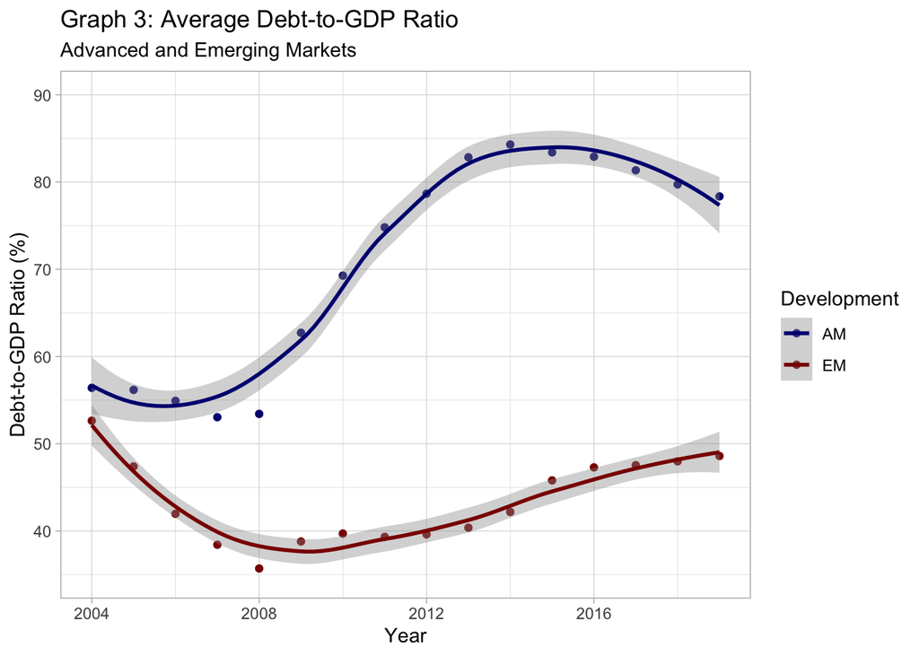

In 2010, the fourth and current global wave of debt began, with characteristics similar to the previous ones: low global interest rates (graph 4) and changes in the financial markets that allowed a rapid debt contraction in both advanced and emerging markets. In 2009, emerging market debt averaged 38 percent of GDP, reaching 48 percent at the end of 2019, while advanced markets grew by around 30 percentage points between 2008 and 2014, when they peaked at 84 percent of GDP on average and ending 2019 at 78 percent (graph 3).

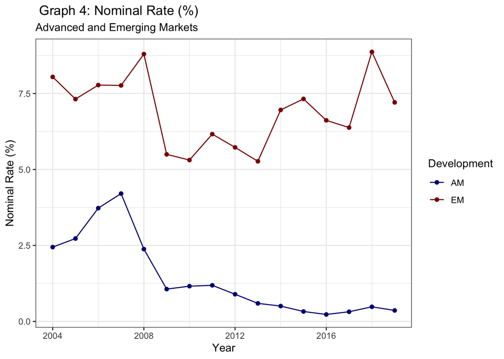

When analyzing foreign participation in public debt, advanced markets have the highest percentage of foreign investors (graph 5), this is due to the greater financial strength and credibility of these countries, thus foreign investors are more willing to access these markets. In addition, they are more tolerant of high foreign participation because they rarely experience abrupt capital reversals. Between 2004 and 2014, advanced markets received around USD 8.5 trillion of foreign investors in public debt, and from that date this capital flow stabilized, with the sum of foreign participation in AM of USD 14.2 trillion in 2019 (graph 6).

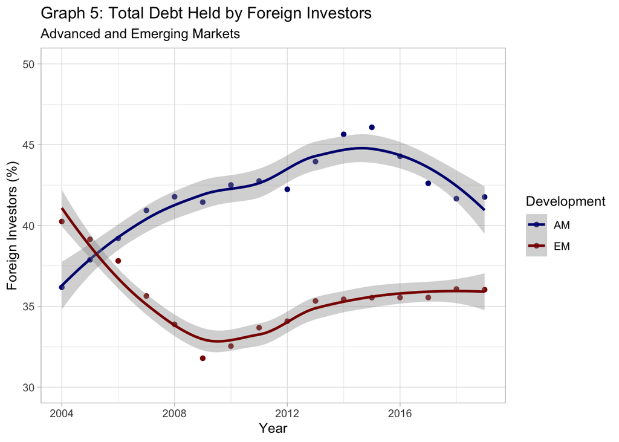

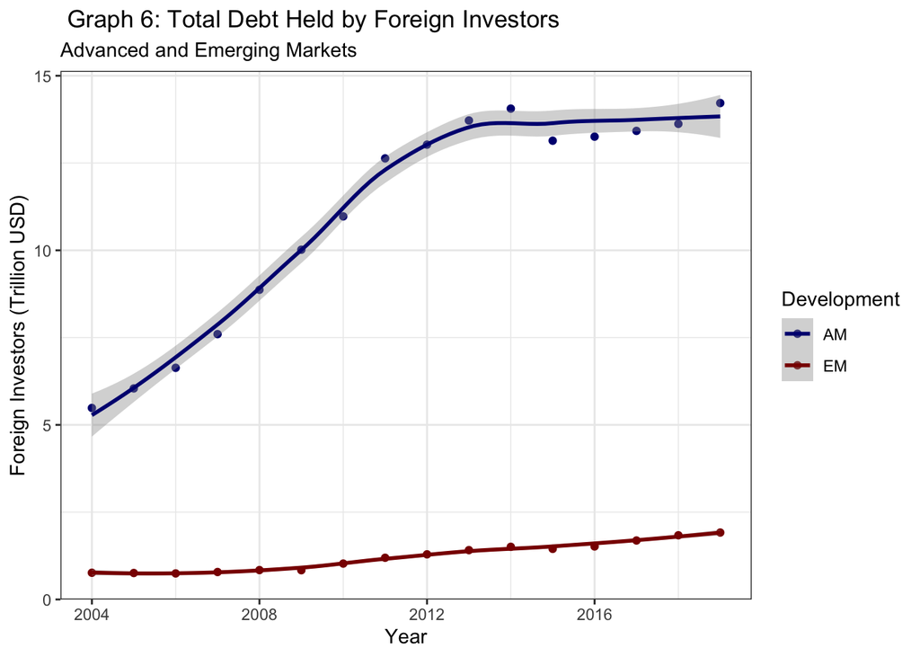

In relation to emerging markets, foreign investors have become important holders of local bonds in recent years. The total of foreign holdings in government bonds from the emerging markets studied, increased from USD 0.74 trillion at the end of 2007 to USD 1.9 trillion in 2019 (graph 6). Foreign flows to EMs have experienced different phases in recent years - pre and post global financial crisis. Before the crisis and until 2009, foreign flows had almost constant variations in the analyzed emerging markets. However, shortly after the crisis, the flow of foreign investors became positive in almost all countries, in addition to a greater magnitude of movements (graphs 7, 8 and 9).

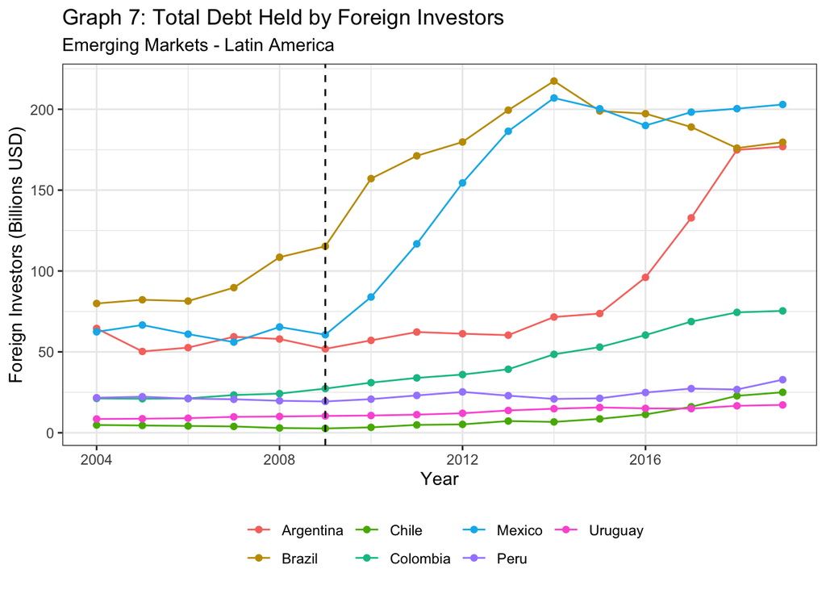

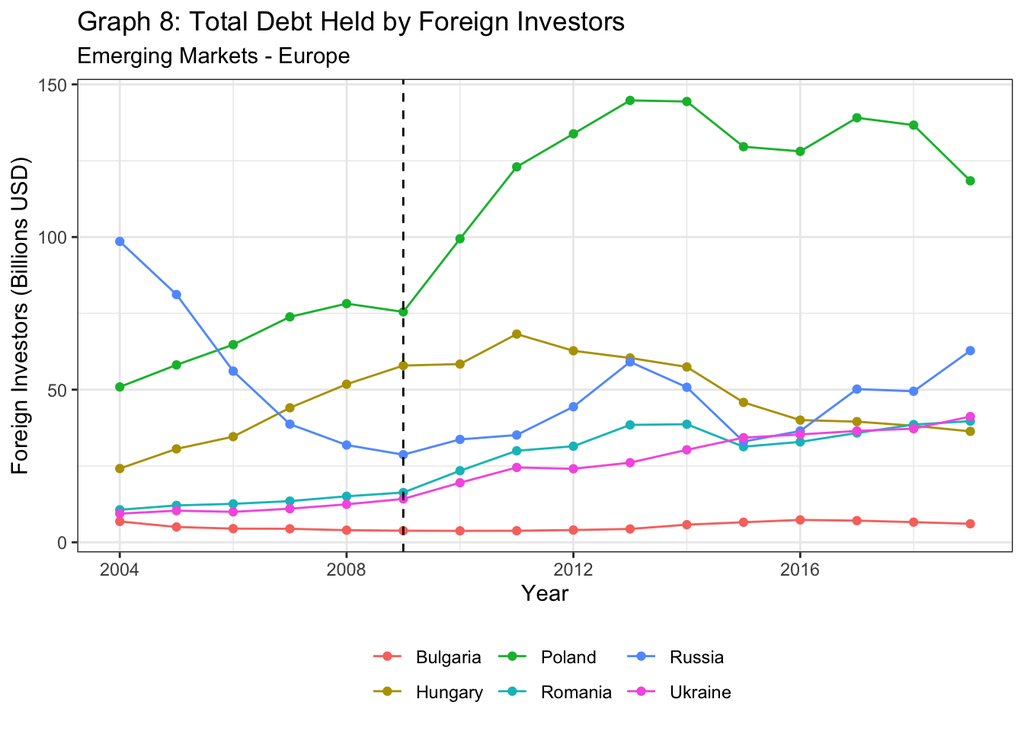

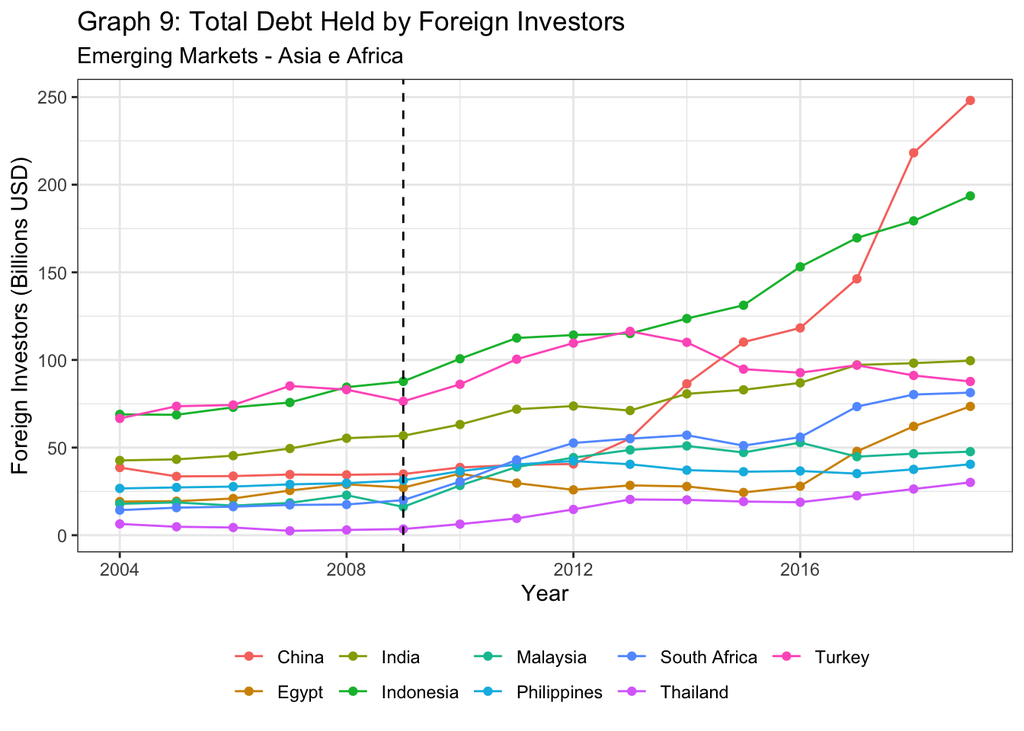

The 2008 global financial crisis caused a strong increase in global risk aversion, as well as a reduction in international liquidity. As a consequence, there was a reversal of capital flows to securities markets in emerging markets and, consequently, a reduction in foreign participation in those markets, between 2008 and 2009. However, shortly after the crisis, international flows to emerging markets were resumed, causing governments in emerging markets to considerably increase the issuance of sovereign debt bonds, in addition to these countries showing an improvement in macroeconomic fundamentals. However, as a consequence, the increase in foreign participation in emerging markets, makes these countries more vulnerable to shocks in investor confidence.

# 6 Other Descriptive Analysis

## 6.1 Evolution of public debt in emerging markets

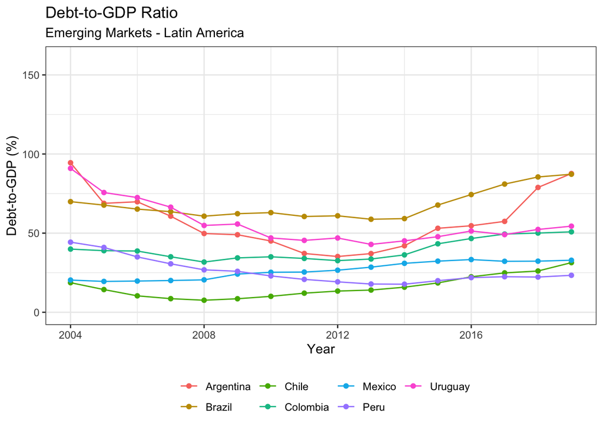

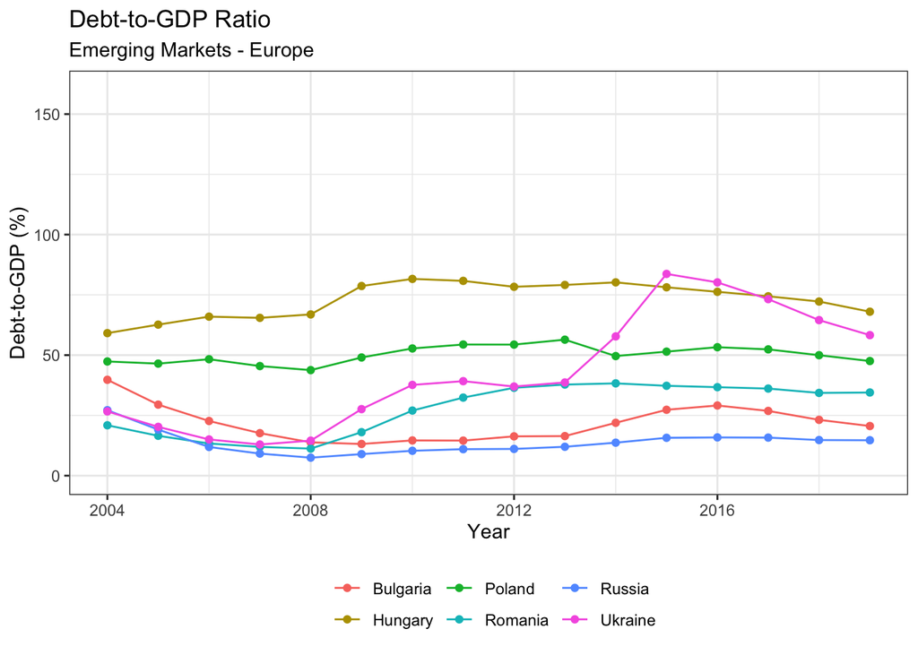

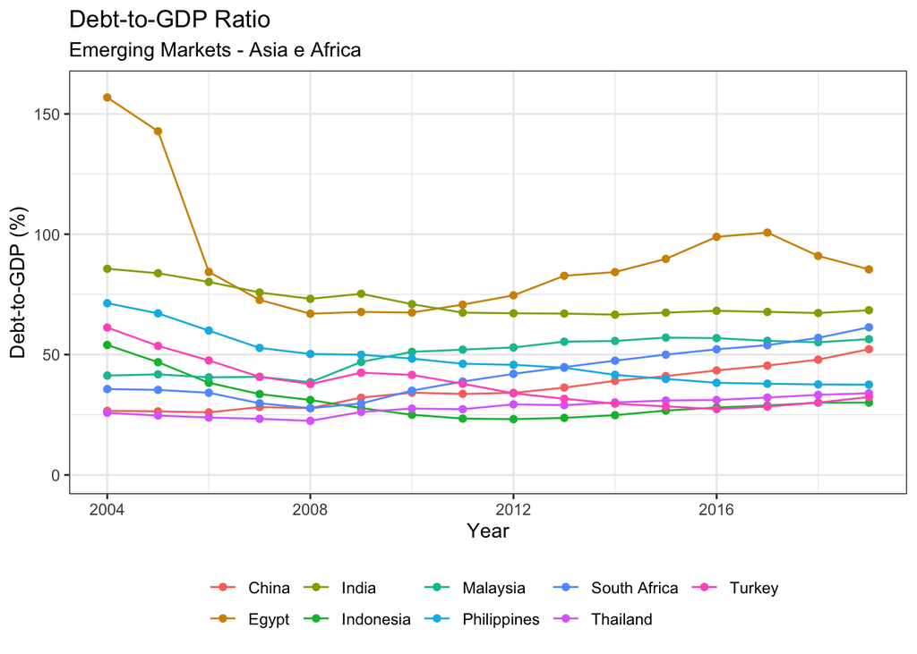

## 6.2 Countries have different indebtedness levels

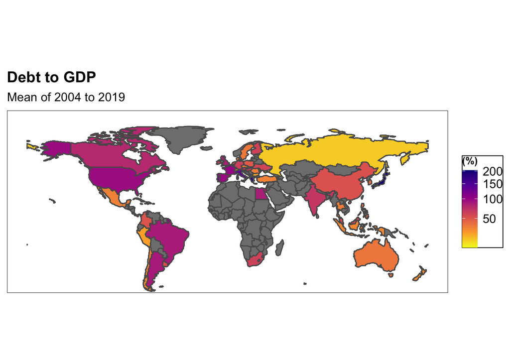

As the map shown above makes clear, countries around the world have contrasting levels of debt to GDP. Nations in grey are not part of our sample.

# 7 Methodology

The methodology used in this study will consist of regressions with panel data. Within and pooled models will be used and compared in order to obtain the most appropriate model. The advantages of using panel data are the possibility to follow the evolution of several countries over time, being able to capture the specific effects of each country and each period of time. In addition, the database was divided between emerging and advanced countries, with the objective of carrying out econometric analysis for these two groups separately.

The regression response variable will be the proportion of foreign participation in the total debt issued by a given country, excluding official institutions. Regarding the explanatory variables are, essentially, macroeconomic fundamentals, such as inflation, policy rate, debt-to-GDP-ratio, the balance of payments, exchange rate volatility, and others. Moreover, dummies to control specific periods of the economy will be included in the model.

The specification of the main model must follow the following equations:

$$\%\;External\;Investors_{it} = \alpha_i \;+ \;\sum{\beta_n \cdot Macro\; Determinants_{it}}\; + \;\sum{\beta_k \cdot Period\;Dummy_{it}} \;\;\;\;\; (1)$$

$$\%\;External\;Investors_{it} = \alpha_t \;+ \;\sum{\beta_n \cdot Macro\; Determinants_{it}}\; + \;\sum{\beta_k \cdot Period\;Dummy_{it}} \;\;\;\;\; (2)$$
$$\%\;External\;Investors_{it} = \alpha_{it} \;+ \;\sum{\beta_n \cdot Macro\; Determinants_{it}}\; + \;\sum{\beta_k \cdot Period\;Dummy_{it}} \;\;\;\; (3)$$
$$\%\;External\;Investors_{it} = \alpha \;+ \;\sum{\beta_n \cdot Macro\; Determinants_{it}}\; + \;\sum{\beta_k \cdot Period\;Dummy_{it}} \;\;\;\;\; (4)$$

As one can see in equations (1) to (4), we ran models with different effects. Model (1) uses country fixed effects; model (2), year fixed effect; model (3), both country and year fixed effect; and lastly model (4) is a pooled cross-section.

# 8 Econometric Results

## 8.1 Regression Results for Advanced Markets

```
##
## Advanced Markets
## ==============================================================
##                                  Dependent variable:
##                        ---------------------------------------
##                         Foreign participation on public debt
##                           (1)        (2)       (3)      (4)
## --------------------------------------------------------------
## debt_to_GDP              0.001     0.0003    0.0005    0.0003
##                         (0.001)    (0.001)   (0.001)  (0.001)
##
## post_08YES               0.041                         -0.052
##                         (0.031)                       (0.056)
##
## ln_GDP_per_cap_cte       -0.002     0.001    -0.002    0.002
##                         (0.001)    (0.003)   (0.001)  (0.003)
##
## nominal_rate            0.018***    0.001    0.018**  -0.0003
##                         (0.007)    (0.011)   (0.008)  (0.010)
##
## lending_borroeing_rate -0.007***  -0.007**  -0.005**  -0.007**
##                         (0.002)    (0.003)   (0.002)  (0.003)
##
## vix_EUA                  0.001                         0.003
##                         (0.001)                       (0.003)
##
## debt_to_GDP:post_08YES -0.001***   -0.001   -0.001***  -0.001
##                         (0.0003)   (0.001)  (0.0003)  (0.001)
##
## Constant                                              0.216***
##                                                       (0.064)
##
## --------------------------------------------------------------
## Country FE                YES        NO        YES       NO
## Year FE                    NO        YES       YES       NO
## Observations              285        285       285      285
## R2                       0.267      0.021     0.103    0.077
## Adjusted R2              0.186     -0.053    -0.049    0.053
## ==============================================================
## Note:                              *p<0.1; **p<0.05; ***p<0.01
```

In view of the results, we must pay attention to those that proved to be significant in our model. Regarding the interest rate, it shows to have a positive effect, when significant, indicating that higher returns attract investors. The lending-borrowing rate has a negative effect, indicating that advanced countries that are creditors to the world receive a smaller flow of foreign capital. And, finally, we have the impact of the interaction between debt-to-GDP ratio and the ‘post 2008’ dummy with a negative effect, indicating a negative capital flow in post 2008 for advanced countries already more indebted.

## 8.2 Regression Results for Emerging Markets

```
##
## Emerging Markets - Threshold comparison
## ==========================================================
##                              Dependent variable:
##                    ---------------------------------------
##                     Foreign participation on public debt
##                       (1)        (2)      (3)       (4)
## ----------------------------------------------------------
## debt_to_GDP         -0.0004   -0.001***  -0.001  -0.001***
##                     (0.0003)  (0.0003)  (0.0003) (0.0003)
##
## post_08YES          0.043***                       0.024
##                     (0.009)                       (0.017)
##
## ln_GDP_per_cap_cte   0.002     -0.002    0.002    -0.002
##                     (0.001)    (0.003)  (0.001)   (0.003)
##
## nominal_rate         -0.001   -0.004**  -0.002** -0.003**
##                     (0.001)    (0.001)  (0.001)   (0.001)
##
## fx_volatility       -0.00001   0.00003  -0.00002  0.00002
##                     (0.0001)  (0.00005) (0.0001) (0.00005)
##
## account_balance      -0.001   -0.006***  -0.001  -0.006***
##                     (0.001)    (0.001)  (0.001)   (0.001)
##
## vix_EUA            -0.004***                     -0.005***
##                     (0.001)                       (0.001)
##
## Constant                                         0.355***
##                                                   (0.034)
##
## ----------------------------------------------------------
## Country FE            YES        NO       YES       NO
## Year FE                NO        YES      YES       NO
## Observations          290        290      290       290
## R2                   0.159      0.133    0.034     0.167
## Adjusted R2          0.068      0.069    -0.126    0.147
## ==========================================================
## Note:                          *p<0.1; **p<0.05; ***p<0.01
```

A very similar regression specification was utilized for the subset of emerging markets. As we already expected, the effects of macroeconomic variables in the participation of foreign investors is largely different from the results seen for advanced economies. First of all, a rise in the debt to GDP level is expected to pull away foreign participation, regardless of the global economy momentum, which is logical and seems to corroborate with the idea of debt intolerance experienced by emerging markets (Reinhart et. al. 2003). At the same time, through a dummy variable indicating the period after the global financial crisis in 2008, we can see that the amount of debt held by foreigners rose in average after 2008.

Finally, it is specially worth of mentioning that, according to our results, one should not expect a rise in foreign share through higher policy rates, which seems to defy the common knowledge, but, as a sort of mirror from what we have found for advanced markets, higher levels of volatility repels the investors from emerging economies to the safer and more advanced ones.

# 9 Initial Conclusions

There are three interesting points that the results revealed and that we would like to explore more. The first is the fact that the variable debt-to-GDP ratio has a negative impact on foreign participation in public debt, when considering emerging countries. In other words, more indebted emerging countries keep investors away.

The second aspect is related to the impact of the United States’ VIX, which is a volatility index. For advanced countries, the variable was not significant. But for emerging countries, it was significant and had a negative effect. Therefore, if the volatility of US markets is considered to represent global volatility, it is possible to interpret that in times of greater uncertainty instability, investors choose to leave emerging countries.

Finally, the third aspect is about the nominal interest rate. For advanced countries, the effect, when significant, is positive. Therefore, higher returns are expected to attract investors in the case of advanced countries. On the other hand, the same cannot be observed for emerging countries, that the effect is negative and significant. One possible explanation for this may be linked to the fact that investors often choose emerging countries to diversify their assets, and not necessarily seeking greater returns. Nonetheless, further investigations and explanations are for this result are needed.

# 10 References

Andritzky, J. R., 2012, “Government Bonds and Their Investors: What Are the Facts and Do They Matter?” IMF Working Paper No. 12/158 (Washington: International Monetary Fund).

Arslanalp, S. and T. Poghosyan, 2014, “Foreign Investor Flows and Sovereign Bond Yields in Advanced Economies” IMF Working Paper 14/27 (Washington: International Monetary Fund).

Arslanalp, S., and Tsuda, T. “Tracking Global Demand for Emerging Market Sovereign Debt” IMF working papers (2014): 14/39

———, and ———. “Tracking Global Demand for Advanced Economy Sovereign Debt” IMF working papers (2012): 12/284

Blanchard, O. J., and L. H. Summers. 2019. Evolution or Revolution? Rethinking Macroeconomic Policy After the Great Recession. Cambridge: MIT Press. Broner, F., T. Didier, A. Erce, and S. Schmukler, (2013). “Gross capital flows: Dynamics and crises”, Journal of Monetary Economics 60, 113-33 Catão, Luis, and Sandeep Kapur. “Volatility and the debt-intolerance paradox.” IMF Staff Papers 53.2 (2006): 195-218.

Deshpande, Ashwini. “The debt overhang and the disincentive to invest.” Journal of development Economics 52.1 (1997): 169-187. Jaramillo L., and S. Zhang, 2013, “Real Money Investors and Sovereign Bond Yields,” IMF Working Paper No. 12/158, (Washington: International Monetary Fund). Krugman, Paul R. Financing vs. forgiving a debt overhang. No. w2486. National Bureau of Economic Research, 1988.

Kumar, Manmohan, and Jaejoon Woo. “Public debt and growth.” IMF working papers (2010): 1-47.

Reinhart, Carmen M., and Kenneth S. Rogoff. “Growth in a Time of Debt.” American economic review 100.2 (2010): 573-78.

Reinhart, Carmen M., Kenneth S. Rogoff, and Miguel A. Savastano. Debt intolerance. No. w9908. National Bureau of Economic Research, 2003.

Reinhart, Carmen M., Vincent R. Reinhart, and Kenneth S. Rogoff. “Public debt overhangs: advanced-economy episodes since 1800.” Journal of Economic Perspectives 26.3 (2012): 69-86.

Rogoff, K. 2019a. “Risks to the Global Economy in 2019.” Project Syndicate, January 11. https://www.project-syndicate.org/commentary/global-economy-mainrisks-in-2019-by-kenneth-rogoff-2019-01.

———. 2019b. “Government Debt is Not A Free Lunch .” Project Syndicate, December 6. https://www.project-syndicate.org/commentary/government-debt-lowinterest-rates-no-free-lunch-by-kenneth-rogoff-2019-11 .

Burger, J., and Warnock, F. (2006). “Local Currency Bond Markets”, IMF Staff Papers, 53: pp. 133–146.

World Bank and International Monetary Fund, 2001, “Developing Government Bond Markets: A Handbook,” World Bank Publications (Washington: International Monetary Fund).